# Simple Linear Regression

Said Sharify

2022-08-08

## Simple Linear Regression

The first thing we do, is to check if the data is linear or not:

```r
library("readr")
WCAT <- read_csv("WCAT.csv")
```

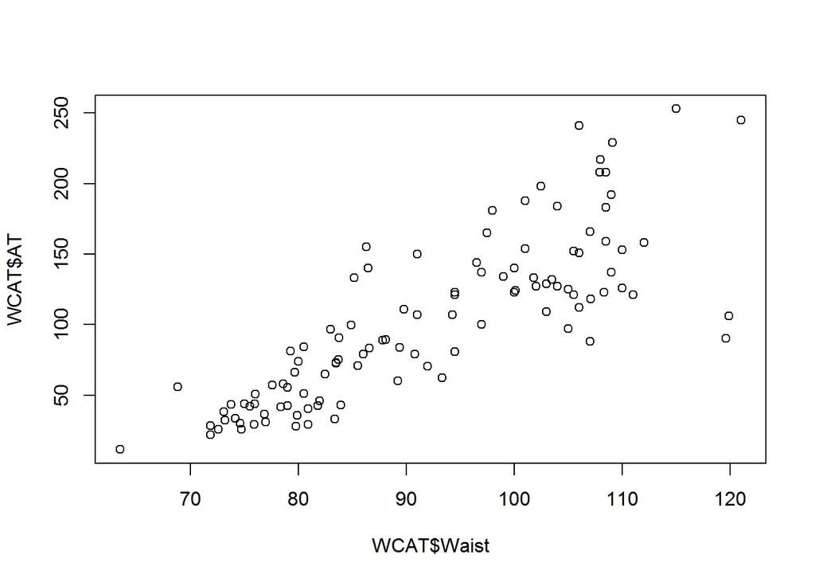

```r
plot(WCAT$Waist, WCAT$AT)
```

We have :

- The correlation is positive,
- The strength of the correlation sounds moderate,
- We can also see a linear relationship.

#### Checking the strength of the correlation

```r
cor(WCAT$Waist, WCAT$AT)
```

```
## [1] 0.8185578
```

For the value $r = 0.8185578$, we can say it is moderate (and not stronge) as it is smaller than $0.85$.

#### Linear Regression model

We can use the lm() function to extract X ~ Y values.

```r
rgistr <- lm(WCAT$Waist ~ WCAT$AT)
summary(rgistr)
```

```
##
## Call:
## lm(formula = WCAT$Waist ~ WCAT$AT)
##
## Residuals:
##     Min      1Q  Median      3Q     Max
## -15.889  -5.205  -1.490   4.010  29.923
##
## Coefficients:
##             Estimate Std. Error t value Pr(>|t|)
## (Intercept) 72.16332    1.53456   47.02   <2e-16 ***
## WCAT$AT      0.19372    0.01314   14.74   <2e-16 ***
## ---
## Signif. codes:  0 '***' 0.001 '**' 0.01 '*' 0.05 '.' 0.1 ' ' 1
##
## Residual standard error: 7.825 on 107 degrees of freedom
## Multiple R-squared:   0.67,  Adjusted R-squared:  0.667
## F-statistic: 217.3 on 1 and 107 DF,  p-value: < 2.2e-16
```

So we have :

- Intercept value = $β0$ = 72.16332
- WCAT$AT value = $β1$ = 0.19372

As the probability associated with a single value is always 0, we need to calculate the range. First, we look at the value of $Pr$. This value will help us to know if the Intercept value and AT value are sufficient to predict the future.

Here the $Pr$, or probability value is calculated as below: $Pr = <2e-16$

With : $Pr < 0.05$ This two values are statistically significant to be used in our prediction.

We also have to check the $R-squared: 0.67$ value, usually it should be greater than 0.8 for a good prediction model.

Insted of getting a single value (Y or AT), we can use R to calculate the confidence interval.

```r
confint(rgistr,  level = 0.95)
```

```
##                  2.5 %     97.5 %
## (Intercept) 69.1212260 75.2054046
## WCAT$AT      0.1676639  0.2197684
```

In order to predict the future with R, we can use the predict function which will predict the values based on the input data :

```r
predict(rgistr,  interval = "predict")
```

```
##           fit       lwr       upr
## 1    77.14569  61.43671  92.85468
## 2    77.17863  61.47020  92.88706
## 3    80.41562  64.75611  96.07513
## 4    80.45437  64.79537  96.11336
## 5    77.94380  62.24802  93.63959
## 6    76.36308  60.64045  92.08571
## 7    77.79658  62.09841  93.49475
## 8    78.55207  62.86586  94.23829
## 9    74.37943  58.61912  90.13974
## 10   78.40485  62.71635  94.09334
## 11   77.64936  61.94878  93.34993
## 12   80.65971  65.00340  96.31601
## 13   79.56521  63.89400  95.23642
## 14   80.39238  64.73256  96.05220
```

[output cut: 95 more lines]

### Transformation

#### Logarithmic

In order to increase the accuracy of the model, and apply the logarithmic model on the trend line, we can use this function in R :

```r
rgistr_log <- lm(WCAT$AT ~ log(WCAT$Waist))
summary(rgistr_log)
```

```
##
## Call:
## lm(formula = WCAT$AT ~ log(WCAT$Waist))
##
## Residuals:
##     Min      1Q  Median      3Q     Max
## -98.473 -18.273  -2.374  14.538  90.400
##
## Coefficients:
##                 Estimate Std. Error t value Pr(>|t|)
## (Intercept)     -1328.34      95.92  -13.85   <2e-16 ***
## log(WCAT$Waist)   317.14      21.26   14.92   <2e-16 ***
## ---
## Signif. codes:  0 '***' 0.001 '**' 0.01 '*' 0.05 '.' 0.1 ' ' 1
##
## Residual standard error: 32.8 on 107 degrees of freedom
## Multiple R-squared:  0.6753, Adjusted R-squared:  0.6723
## F-statistic: 222.6 on 1 and 107 DF,  p-value: < 2.2e-16
```

```r
confint(rgistr_log, level = 0.95)
```

```
##                      2.5 %     97.5 %
## (Intercept)     -1518.4980 -1138.1860
## log(WCAT$Waist)   274.9936   359.2775
```

We can see the values are changed slightly, as the equation is changed as below :

- AT = -1328.34 + 317.14 ($log$(Input))

#### Exponential

We can also apply the exponential option over the trend line.

```r
rgistr_exp <- lm(log(WCAT$AT) ~ (WCAT$Waist))
summary(rgistr_exp)
```

```
##
## Call:
## lm(formula = log(WCAT$AT) ~ (WCAT$Waist))
##
## Residuals:
##      Min       1Q   Median       3Q      Max
## -1.05086 -0.21688  0.03623  0.23044  0.82862
##
## Coefficients:
##             Estimate Std. Error t value Pr(>|t|)
## (Intercept) 0.741021   0.232628   3.185  0.00189 **
## WCAT$Waist  0.040252   0.002504  16.073  < 2e-16 ***
## ---
## Signif. codes:  0 '***' 0.001 '**' 0.01 '*' 0.05 '.' 0.1 ' ' 1
##
## Residual standard error: 0.3529 on 107 degrees of freedom
## Multiple R-squared:  0.7071, Adjusted R-squared:  0.7044
## F-statistic: 258.3 on 1 and 107 DF,  p-value: < 2.2e-16
```

```r
confint(rgistr_exp, level = 0.95)
```

```
##                  2.5 %     97.5 %
## (Intercept) 0.27986215 1.20217913
## WCAT$Waist  0.03528773 0.04521711
```

So the equation is changed as below :

- $log$(AT) = 0.741021 + 0.040252 (Input)
- AT = $exp$ (0.741021 + 0.040252 (Input))

#### Polynomial

```r
rgistr_pol <- lm((WCAT$AT) ~ (WCAT$Waist) + (WCAT$Waist)^2 + (WCAT$Waist)^3)
summary(rgistr_pol)
```

```
##
## Call:
## lm(formula = (WCAT$AT) ~ (WCAT$Waist) + (WCAT$Waist)^2 + (WCAT$Waist)^3)
##
## Residuals:
##      Min       1Q   Median       3Q      Max
## -107.288  -19.143   -2.939   16.376   90.342
##
## Coefficients:
##              Estimate Std. Error t value Pr(>|t|)
## (Intercept) -215.9815    21.7963  -9.909   <2e-16 ***
## WCAT$Waist     3.4589     0.2347  14.740   <2e-16 ***
## ---
## Signif. codes:  0 '***' 0.001 '**' 0.01 '*' 0.05 '.' 0.1 ' ' 1
##
## Residual standard error: 33.06 on 107 degrees of freedom
## Multiple R-squared:   0.67,  Adjusted R-squared:  0.667
## F-statistic: 217.3 on 1 and 107 DF,  p-value: < 2.2e-16
```

```r
confint(rgistr_pol, level = 0.95)
```

```
##                   2.5 %     97.5 %
## (Intercept) -259.190053 -172.77292
## WCAT$Waist     2.993689    3.92403
```

#### Note

Calculated values from these transformations, could be used in Tableau to visualize different presentations of data over the trend line.